# The role of language context in the acquisition of novel words

- *Anna Alberski & Kathryn Schuler*
- Short talk at CUNY 2021

## Setting up

Before we do the analysis, we need to load in our libraries and read in our data. This analysis was done in a [jupyter/datascience-notebook:4.0.3](https://hub.docker.com/r/jupyter/datascience-notebook/) docker container.

```r
# load tidyverse, but be quiet about it
options(tidyverse.quiet = TRUE)
library(tidyverse)

# load other libraries we'll need
library(knitr) # for nice tables
library(lme4) # for mixed effects models

# turn off annoying "summarise()" warning in new dplyr
options(dplyr.summarise.inform = FALSE)

# theme and base size of figures
theme_set(theme_classic(base_size = 20))
```

```r
# load the data!
data <- read.csv('data_anonymized.csv') %>%
    mutate(experiment = "Adult Pilot Experiment")
```

## Participants

Get the number of participants in the study

```r
n_distinct(data$random_id)
```

25

## Accuracy

How accurate were participants at selecting the target? From the figure below, everyone was 100% accurate. This is not surprising because it's not that hard!

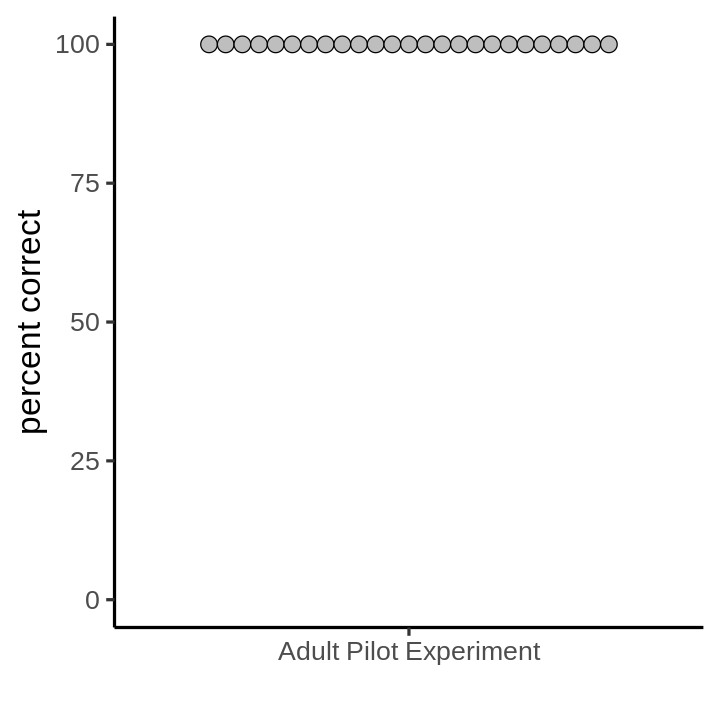

```r
# set the figure size
options(repr.plot.width = 6, repr.plot.height = 6)

# plot accuracy for each person as dotplot
data %>% group_by(experiment, random_id) %>%
    summarise(n = n(), ncorr = sum(is_correct), pcorr = ncorr/n*100) %>%
    ggplot(aes(x = factor(experiment), y = pcorr)) +
    geom_dotplot(binaxis = "y", stackdir = "center", binwidth = 3, fill = "grey") +
    coord_cartesian(ylim = c(0, 100)) +
    labs(x = "", y = "percent correct")
```

## Reaction time

Get the reaction times for each person in two ways to make the figure. Median RT by language context and type and Mean Log RT by the same. We'll then take the mean of each to make the figure.

### Plot reaction time data

```r
# for each participant, we'll get the median rt for each langcont x wordtype
# and also their mean log transformed rt for the same
rt_by_context <- data %>%
    group_by(random_id, langcont, wordtype) %>%
    summarise(medianrt = median(rt), meanlogrt = mean(log_rt)) %>%
    gather("rt_type", "rt", 4:5)
```

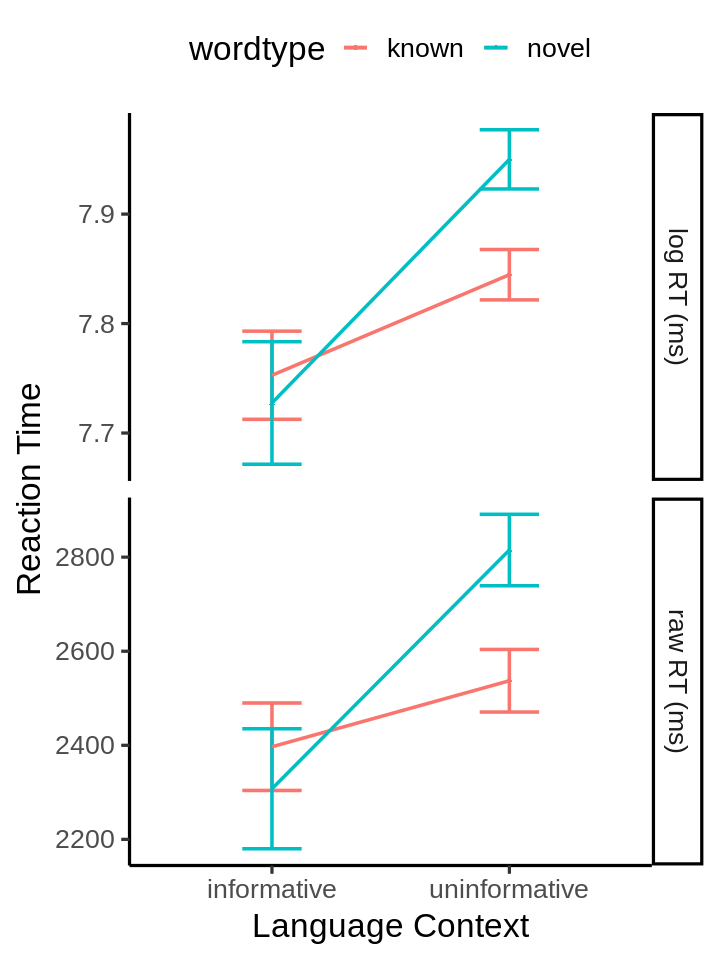

```r
# set the figure size
options(repr.plot.width = 6, repr.plot.height = 8)

# setup labels for the figure
rt.labs <- c("log RT (ms)", "raw RT (ms)")
names(rt.labs) <- c("meanlogrt", "medianrt")

# plot the mean of what we calculated for each participant
ggplot(rt_by_context, aes(y = rt, x = langcont, color = wordtype)) +
    facet_grid(rt_type ~ ., scales = "free_y", labeller = labeller(rt_type = rt.labs ))+
    stat_summary(fun = mean, geom = "point", aes(shape = wordtype), size = 1) +
    stat_summary(fun.data = mean_se, geom = "errorbar", width = 0.25, size = 1) +
    stat_summary(fun = mean, geom = "line", aes(group = wordtype), size = 1) +
    theme_classic(base_size = 20) +
    labs(x = 'Language Context', y = 'Reaction Time') +
    theme(legend.position = "top")
```

The figure suggests participants were slower in the uninformative context and slower for novel words, but novel words are only slower if they are in an uninformative context.

### Model reaction time data

```r
# setup the data for the model
model_data <- data %>%
    mutate(wordtype = factor(wordtype),
          langcont = factor(langcont))

# use simple coding so the main effects are easier to interpret (two levels)
c2 <- contr.treatment(2)
coding2 <- matrix(rep(1/2, 2), ncol=1)
simple2 <- c2-coding2


contrasts(model_data$wordtype) <- simple2
contrasts(model_data$langcont) <- simple2
```

#### Raw RT

Mixed-effect regression predicting raw RT by word type and language context

```r
exp.null <- lmer(rt ~ 1 + (1|random_id), data = model_data)

# incrementally build up model to test for main effects and interaction
exp.wordtype <- update(exp.null, .~. + wordtype)
exp.langcont <- update(exp.wordtype, .~. + langcont)
exp.typecont <- update(exp.langcont, .~. + wordtype:langcont)
```

```r
# test for main effects and interactions
anova(exp.null, exp.wordtype, exp.langcont, exp.typecont)
```

```
refitting model(s) with ML (instead of REML)
```

A anova: 4 × 8

|  | npar <dbl> | AIC <dbl> | BIC <dbl> | logLik <dbl> | deviance <dbl> | Chisq <dbl> | Df <dbl> | Pr(>Chisq) <dbl> |
| --- | --- | --- | --- | --- | --- | --- | --- | --- |
| exp.null | 3 | 8896.900 | 8909.932 | -4445.450 | 8890.900 | NA | NA | NA |
| exp.wordtype | 4 | 8890.519 | 8907.895 | -4441.260 | 8882.519 | 8.381127 | 1 | 3.791372e-03 |
| exp.langcont | 5 | 8837.099 | 8858.818 | -4413.549 | 8827.099 | 55.420491 | 1 | 9.731667e-14 |
| exp.typecont | 6 | 8825.732 | 8851.796 | -4406.866 | 8813.732 | 13.366428 | 1 | 2.561688e-04 |

There is a main effect of word type, a main effect of language context, and an interaction between word type and language context. This matches nicely with what we see in the figure.

```r
# show the coefficients
summary(exp.typecont)$coefficients
```

A matrix: 4 × 3 of type dbl

|  | Estimate | Std. Error | t value |
| --- | --- | --- | --- |
| (Intercept) | 2569.1200 | 76.77390 | 33.463457 |
| wordtype2 | 143.7876 | 44.66162 | 3.219489 |
| langcont2 | 350.3868 | 44.61811 | 7.853017 |
| wordtype2:langcont2 | 327.2224 | 89.22718 | 3.667295 |

#### Log RT

```r
explog.null <- lmer(log_rt ~ 1 + (1|random_id), data = model_data)

# incrementally build up model to test for main effects and interaction
explog.wordtype <- update(explog.null, .~. + wordtype)
explog.langcont <- update(explog.wordtype, .~. + langcont)
explog.typecont <- update(explog.langcont, .~. + wordtype:langcont)
```

```r
# test for main effects and interactions
anova(explog.null, explog.wordtype, explog.langcont, explog.typecont)
```

```
refitting model(s) with ML (instead of REML)
```

A anova: 4 × 8

|  | npar <dbl> | AIC <dbl> | BIC <dbl> | logLik <dbl> | deviance <dbl> | Chisq <dbl> | Df <dbl> | Pr(>Chisq) <dbl> |
| --- | --- | --- | --- | --- | --- | --- | --- | --- |
| explog.null | 3 | -21.36192 | -8.330282 | 13.68096 | -27.36192 | NA | NA | NA |
| explog.wordtype | 4 | -22.44691 | -5.071387 | 15.22345 | -30.44691 | 3.084986 | 1 | 7.901795e-02 |
| explog.langcont | 5 | -99.28256 | -77.563161 | 54.64128 | -109.28256 | 78.835654 | 1 | 6.749781e-19 |
| explog.typecont | 6 | -113.50773 | -87.444444 | 62.75386 | -125.50773 | 16.225164 | 1 | 5.624207e-05 |

```r
# show the coefficients
summary(explog.typecont)$coefficients
```

A matrix: 4 × 3 of type dbl

|  | Estimate | Std. Error | t value |
| --- | --- | --- | --- |
| (Intercept) | 7.81705637 | 0.03114277 | 251.007076 |
| wordtype2 | 0.03576138 | 0.01728068 | 2.069443 |
| langcont2 | 0.16363278 | 0.01726368 | 9.478439 |
| wordtype2:langcont2 | 0.13968043 | 0.03452383 | 4.045914 |